# R Notebook

```r
homoloGene<-read.csv(file = "m_h_HomoloPair.txt",header=T,sep=" ",stringsAsFactors = F)
homoloGene$comName<-paste(homoloGene$mGNameInData,homoloGene$V1,sep="_")
```

`r`r dim(seurat_E15E16P1P4_wt@raw.data)

```
[1] 21911 16809
```

`r`r mouse_wt_matrix@Dimnames[1]<-as.list(homoloGene$comName[homoloGene$mGNameInData %in% unlist(seurat_E15E16P1P4_wt@raw.data@Dimnames[1])])

```
number of items to replace is not a multiple of replacement length
```

##### in the matrix above, genes with multiple homologs in the other species (hence shows in multiple rows in “homoloGene”) also appear multiple times (each time with a unique “comName”.)

`r`r human_matrix<-Hs_GA2123_Trachea_v3@raw.data[homoloGene$V1[homoloGene$V1 %in% unlist(Hs_GA2123_Trachea_v3@raw.data@Dimnames[1])],Hs_GA2123_Trachea_v3@cell.names] human_matrix@Dimnames[1]<-list(homoloGene$comName[homoloGene$V1 %in% unlist(Hs_GA2123_Trachea_v3@raw.data@Dimnames[1])])

```r
seu_mE16_homo<-CreateSeuratObject(raw.data = mouse_wt_E16_matrix, min.cells = 1, min.genes = 1,
    project = "mouse_E16_HomoloGene")
```

```r
seu_human_homo<-CreateSeuratObject(raw.data = human_matrix, min.cells = 1, min.genes = 1,
    project = "human_HomoloGene")
```

##### merging 2 seurat objects give 18199 genes (16732 genes from the mouse object and 17550 from the human object. merging returns the union. missing genes in either objects become 0 in the merged object):

`r`r seu_mE16_human_homo<-MergeSeurat(object1 = seu_mE16_homo,object2 = seu_human_homo,min.cells = 0,min.genes = 0,is.expr = 0,do.normalize = T,scale.factor = 10000)

`r`r table(seu_mE16_human_homo@meta.data$orig.ident)

```
   E16 GA21wk GA23wk
  8432   7623   2070
```

```r
mouse_annotation<-seurat_E15E16P1P4_wt@meta.data$specific_type
names(mouse_annotation)<-seurat_E15E16P1P4_wt@cell.names
human_annotation<-Hs_GA2123_Trachea_v3@meta.data$specific_type
names(human_annotation)<-Hs_GA2123_Trachea_v3@cell.names
seu_mE16_human_homo<-AddMetaData(object = seu_mE16_human_homo, metadata = c(mouse_annotation,human_annotation), col.name = "specific_type")
```

`r`r table(seu_mE16_human_homo@meta.data$species,seu_mE16_human_homo@meta.data$specific_type)

```
        Basal Basal_SE Basal_SMG Chondrocyte CiliaSecretory Ciliated Ciliated_Foxn4 CyclingEpithelial CyclingFibroblast Doublet Epcam_ECM Fibroblast Immune Immune_1
  Human     0      308        30         650              0      169             66                 0               479       0       150       5359    121        0
  Mouse  1324        0         0         617              3      294              0               132               810      87         0       2914      0      163

        Immune_2 LymphaticEndothelial MesenchymalProgenitor Muscle Myoepithelial Neuron/NEC  RBC SchwannCell Schwann/Neural Secretory Secretory_SE Secretory_SMG Stem
  Human        0                   65                   316    177            67          0    0           0            405         0           54           176  286
  Mouse       78                   48                   199    285             0         15   53          53              0      1094            0             0    0

        Thyroid Transitional VascularEndothelial VSMC/pericyte
  Human       0            0                 815             0
  Mouse      22            0                 182            59
```

```r
seu_mE16_human_homo@meta.data$annotation<-as.character(seu_mE16_human_homo@meta.data$specific_type)
seu_mE16_human_homo@meta.data$annotation[seu_mE16_human_homo@meta.data$annotation=="Ciliated_Foxn4"]<-"Ciliated"
seu_mE16_human_homo@meta.data$annotation[seu_mE16_human_homo@meta.data$annotation=="Immune_1"]<-"Immune"
seu_mE16_human_homo@meta.data$annotation[seu_mE16_human_homo@meta.data$annotation=="Immune_2"]<-"Immune"
seu_mE16_human_homo@meta.data$annotation[seu_mE16_human_homo@meta.data$annotation=="Neuron/NEC"]<-"Schwann/Neural"
seu_mE16_human_homo@meta.data$annotation[seu_mE16_human_homo@meta.data$annotation=="SchwannCell"]<-"Schwann/Neural"
seu_mE16_human_homo@meta.data$annotation[seu_mE16_human_homo@meta.data$annotation=="VSMC/pericyte"]<-"Muscle"
#SplitDotPlotGG cannot deal with annotations with an underscore, so I need to change all underscores:
seu_mE16_human_homo@meta.data$annotation[seu_mE16_human_homo@meta.data$annotation=="Basal_SE"]<-"BasalSE"
seu_mE16_human_homo@meta.data$annotation[seu_mE16_human_homo@meta.data$annotation=="Basal_SMG"]<-"BasalSMG"
seu_mE16_human_homo@meta.data$annotation[seu_mE16_human_homo@meta.data$annotation=="Secretory_SMG"]<-"SecretorySMG"
seu_mE16_human_homo@meta.data$annotation[seu_mE16_human_homo@meta.data$annotation=="Secretory_SE"]<-"SecretorySE"
```

```r
table(seu_mE16_human_homo@meta.data$species,seu_mE16_human_homo@meta.data$annotation)
```

```
        Basal BasalSE BasalSMG Chondrocyte CiliaSecretory Ciliated CyclingEpithelial CyclingFibroblast Doublet EpcamECM Fibroblast Immune LymphaticEndothelial
  Human     0     308       30         650              0      235                 0               479       0      150       5359    121                   65
  Mouse  1324       0        0         617              3      294               132               810      87        0       2914    241                   48

        MesenchymalProgenitor Muscle Myoepithelial  RBC Schwann/Neural Secretory SecretorySE SecretorySMG Stem Thyroid VascularEndothelial
  Human                   316    177            67    0            405         0          54          176  286       0                 815
  Mouse                   199    344             0   53             68      1094           0            0    0      22                 182
```

```r
seu_mE16_human_homo@meta.data$speciesXannotation<-paste(seu_mE16_human_homo@meta.data$species,seu_mE16_human_homo@meta.data$annotation,sep="_")
```

```r
table(seu_mE16_human_homo@meta.data$speciesXannotation)
```

```
              Human_BasalSE              Human_BasalSMG           Human_Chondrocyte              Human_Ciliated     Human_CyclingFibroblast
                        308                          30                         650                         235                         479
            Human_Epcam_ECM            Human_Fibroblast                Human_Immune  Human_LymphaticEndothelial Human_MesenchymalProgenitor
                        150                        5359                         121                          65                         316
               Human_Muscle         Human_Myoepithelial        Human_Schwann/Neural           Human_SecretorySE          Human_SecretorySMG
                        177                          67                         405                          54                         176
                 Human_Stem   Human_VascularEndothelial                 Mouse_Basal           Mouse_Chondrocyte        Mouse_CiliaSecretory
                        286                         815                        1324                         617                           3
             Mouse_Ciliated     Mouse_CyclingEpithelial     Mouse_CyclingFibroblast               Mouse_Doublet            Mouse_Fibroblast
                        294                         132                         810                          87                        2914
               Mouse_Immune  Mouse_LymphaticEndothelial Mouse_MesenchymalProgenitor                Mouse_Muscle                   Mouse_RBC
                        241                          48                         199                         344                          53
       Mouse_Schwann/Neural             Mouse_Secretory               Mouse_Thyroid   Mouse_VascularEndothelial
                         68                        1094                          22                         182
```

```r
seu_mE16_human_homo <- ScaleData(object = seu_mE16_human_homo)
```

```
Scaling data matrix
```

```r
seu_mE16_human_homo<-SetAllIdent(object = seu_mE16_human_homo, id = "annotation")
print(levels(seu_mE16_human_homo@ident))
```

```
 [1] "Basal"                 "BasalSE"               "BasalSMG"              "Chondrocyte"           "CiliaSecretory"        "Ciliated"
 [7] "CyclingEpithelial"     "CyclingFibroblast"     "Doublet"               "EpcamECM"              "Fibroblast"            "Immune"
[13] "LymphaticEndothelial"  "MesenchymalProgenitor" "Muscle"                "Myoepithelial"         "RBC"                   "Schwann/Neural"
[19] "Secretory"             "SecretorySE"           "SecretorySMG"          "Stem"                  "Thyroid"               "VascularEndothelial"
```

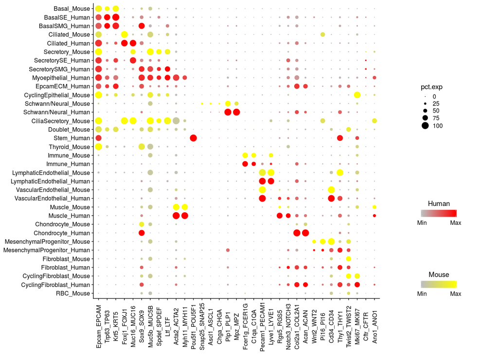

```r
seu_mE16_human_homo@ident = factor(seu_mE16_human_homo@ident,levels(seu_mE16_human_homo@ident)[rev(c(1:3,6,19:21,16,10,7,18,5,9,22,23,12,13,24,15,4,14,11,8,17))])
#seu_mE16_human_homo@ident = factor(seu_mE16_human_homo@ident,levels(seu_mE16_human_homo@ident)[rev(c(1:3,6,19:21,16,10,7,18,12,13,24,15,4,14,11,8))])
SplitDotPlotGG(seu_mE16_human_homo,grouping.var = "species",genes.plot =rev( c("Epcam_EPCAM","Trp63_TP63","Krt5_KRT5","Foxj1_FOXJ1","Muc16_MUC16","Sox9_SOX9","Muc5b_MUC5B","Spdef_SPDEF","Ltf_LTF","Acta2_ACTA2","Myh11_MYH11","Pou5f1_POU5F1","Snap25_SNAP25","Ascl1_ASCL1","Chga_CHGA","Plp1_PLP1","Mpz_MPZ","Fcer1g_FCER1G","C1qa_C1QA","Pecam1_PECAM1","Lyve1_LYVE1","Rgs5_RGS5","Notch3_NOTCH3","Col2a1_COL2A1","Acan_ACAN","Wnt2_WNT2","Pi16_PI16","Cd34_CD34","Thy1_THY1","Twist2_TWIST2","Mki67_MKI67","Cftr_CFTR","Ano1_ANO1")),x.lab.rot =T,plot.legend  =T,cols.use = c("red","yellow"))
```

```r
seu_mE16_human_homo<-SetAllIdent(object = seu_mE16_human_homo, id = "annotation_colaps")
print(levels(seu_mE16_human_homo@ident))
```

```
 [1] "Basal"                 "BasalSE"               "BasalSMG"              "Chondrocyte"           "CiliaSecretory"        "Ciliated"
 [7] "CyclingEpithelial"     "CyclingFibroblast"     "EpcamECM"              "Fibroblast"            "Immune"                "LymphaticEndothelial"
[13] "MesenchymalProgenitor" "Muscle"                "Myoepithelial"         "Others"                "Schwann/Neural"        "Secretory"
[19] "SecretorySE"           "SecretorySMG"          "VascularEndothelial"
```

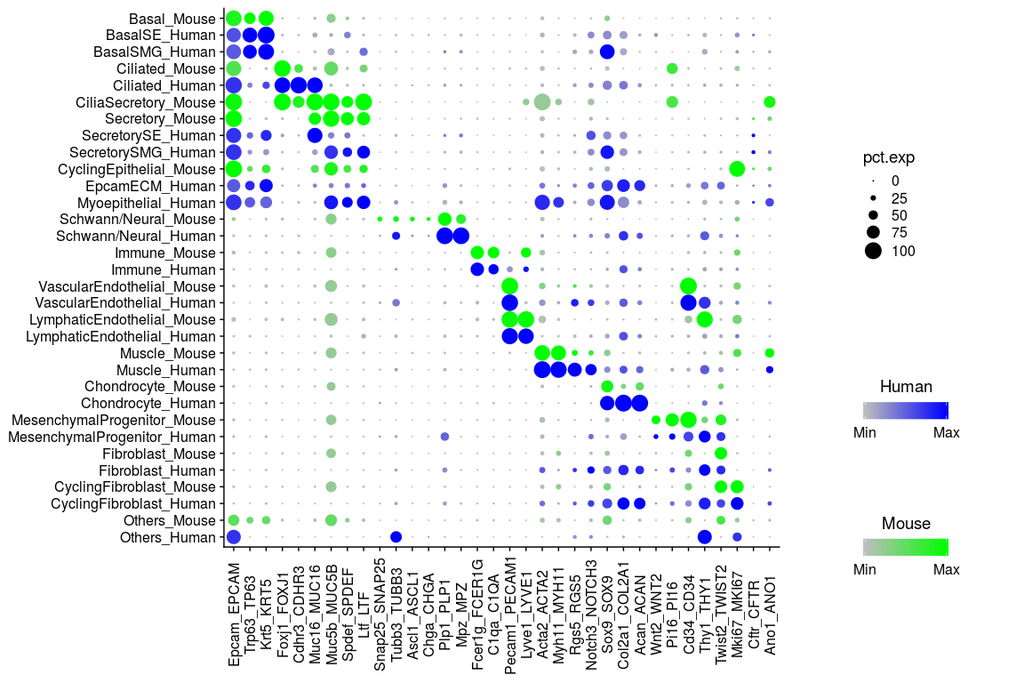

```r
seu_mE16_human_homo@ident = factor(seu_mE16_human_homo@ident,levels(seu_mE16_human_homo@ident)[rev(c(1:3,6,5,18:20,7,9,15,17,11,21,12,14,4,13,10,8,16))])
#seu_mE16_human_homo@ident = factor(seu_mE16_human_homo@ident,levels(seu_mE16_human_homo@ident)[rev(c(1:3,6,19:21,16,10,7,18,12,13,24,15,4,14,11,8))])
SplitDotPlotGG(seu_mE16_human_homo,grouping.var = "species",genes.plot =rev( c("Epcam_EPCAM","Trp63_TP63","Krt5_KRT5","Foxj1_FOXJ1","Cdhr3_CDHR3","Muc16_MUC16","Muc5b_MUC5B","Spdef_SPDEF","Ltf_LTF","Snap25_SNAP25","Tubb3_TUBB3","Ascl1_ASCL1","Chga_CHGA","Plp1_PLP1","Mpz_MPZ","Fcer1g_FCER1G","C1qa_C1QA","Pecam1_PECAM1","Lyve1_LYVE1","Acta2_ACTA2","Myh11_MYH11","Rgs5_RGS5","Notch3_NOTCH3","Sox9_SOX9","Col2a1_COL2A1","Acan_ACAN","Wnt2_WNT2","Pi16_PI16","Cd34_CD34","Thy1_THY1","Twist2_TWIST2","Mki67_MKI67","Cftr_CFTR","Ano1_ANO1")),x.lab.rot =T,plot.legend  =T,cols.use = c("blue","green"),col.min = -1,col.max = 2)
```

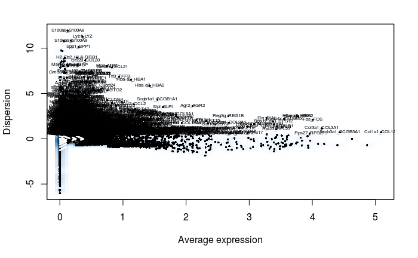

```r
seu_mE16_human_homo <- FindVariableGenes(object = seu_mE16_human_homo, do.plot = TRUE, x.low.cutoff=0.1,x.high.cutoff = Inf, y.cutoff = 0.5)
```

```r
seu_mE16_human_homo <- RunPCA(object = seu_mE16_human_homo, do.print = FALSE)
seu_mE16_human_homo <- ProjectPCA(object = seu_mE16_human_homo, do.print = FALSE)
```

```r
#PCHeatmap(object = seu_mE16_human_homo, pc.use = 1:10, cells.use = 500, do.balanced = TRUE, label.columns = FALSE, num.genes = 25)
```

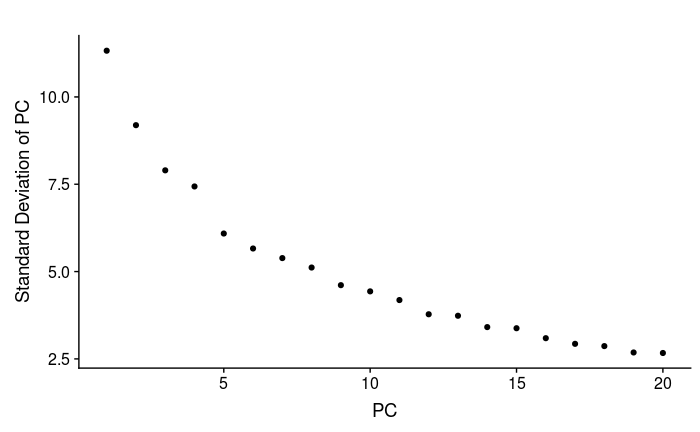

```r
PCElbowPlot(object = seu_mE16_human_homo)
```

```r
n.pcs = 20
res.used <- 0.8
seu_mE16_human_homo <- FindClusters(object = seu_mE16_human_homo, reduction.type = "pca", dims.use = 1:n.pcs,
    resolution = res.used, print.output = 0, save.SNN = TRUE)
```

```r
seu_mE16_human_homo <- RunTSNE(object = seu_mE16_human_homo, dims.use = 1:n.pcs, seed.use = 10, perplexity=30, dim.embed = 2)
```

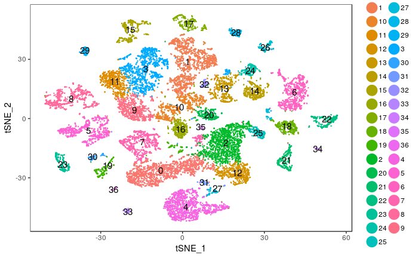

```r
TSNEPlot(object = seu_mE16_human_homo, do.label = T,group.by="res.0.8",pt.size = 0.2)
```

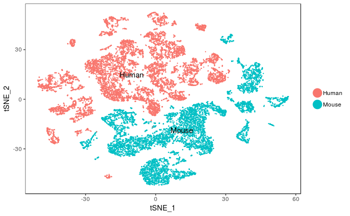

[output not shown]

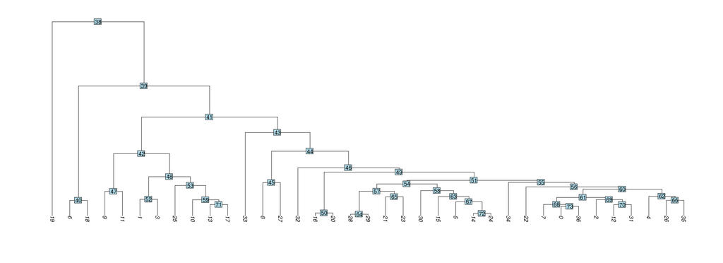

```r
seu_mE16_human_homo=buildClusterTree(seu_mE16_human_homo,do.reorder = F,reorder.numeric = F)
```

```r
seu_mE16_human_homo<-SetAllIdent(object = seu_mE16_human_homo, id = "speciesXannotation")
average_human_homo_speciesXannotation<-AverageExpression(object = seu_mE16_human_homo,return.seurat = T)
```

[output not shown]

```r
correlation_scaled <- cor(average_human_homo_speciesXannotation@scale.data)
round(correlation_scaled, 2)
```

```
                            Human_Basal_SE Human_Basal_SMG Human_Chondrocyte Human_Ciliated Human_CyclingFibroblast Human_Epcam_ECM Human_Fibroblast Human_Immune
Human_Basal_SE                        1.00            0.46              0.10           0.24                    0.10            0.53             0.10         0.06
Human_Basal_SMG                       0.46            1.00              0.09           0.14                    0.09            0.37             0.10         0.03
Human_Chondrocyte                     0.10            0.09              1.00           0.04                    0.29            0.29             0.37         0.08
Human_Ciliated                        0.24            0.14              0.04           1.00                   -0.02            0.19            -0.01        -0.01
Human_CyclingFibroblast               0.10            0.09              0.29          -0.02                    1.00            0.30             0.44         0.05
Human_Epcam_ECM                       0.53            0.37              0.29           0.19                    0.30            1.00             0.39         0.06
Human_Fibroblast                      0.10            0.10              0.37          -0.01                    0.44            0.39             1.00         0.03
Human_Immune                          0.06            0.03              0.08          -0.01                    0.05            0.06             0.03         1.00
Human_LymphaticEndothelial            0.09            0.09              0.05           0.05                    0.12            0.16             0.15         0.11
Human_MesenchymalProgenitor           0.09            0.08              0.28           0.02                    0.40            0.35             0.56         0.04
Human_Muscle                          0.13            0.13              0.20           0.03                    0.29            0.28             0.39         0.05
Human_Myoepithelial                   0.33            0.33              0.16           0.16                    0.08            0.34             0.12         0.05
Human_Schwann/Neural                  0.14            0.16              0.22           0.02                    0.29            0.27             0.32         0.05
Human_Secretory_SE                    0.49            0.27              0.07           0.29                    0.00            0.34             0.02         0.06
Human_Secretory_SMG                   0.35            0.31              0.19           0.26                   -0.01            0.34             0.08         0.08
Human_Stem                            0.06            0.04              0.03          -0.03                    0.15           -0.02            -0.03         0.02
Human_VascularEndothelial             0.15            0.13              0.11           0.04                    0.16            0.21             0.23         0.12
Mouse_Basal                          -0.14           -0.14             -0.26          -0.17                   -0.35           -0.29            -0.34        -0.19
Mouse_Chondrocyte                    -0.34           -0.27             -0.13          -0.29                   -0.21           -0.29            -0.13        -0.22
Mouse_CiliaSecretory                 -0.15           -0.14             -0.15           0.01                   -0.24           -0.20            -0.21        -0.09
Mouse_Ciliated                       -0.18           -0.16             -0.19           0.11                   -0.20           -0.27            -0.28        -0.16
Mouse_CyclingEpithelial              -0.20           -0.20             -0.31          -0.17                   -0.15           -0.36            -0.40        -0.18
Mouse_CyclingFibroblast              -0.36           -0.29             -0.23          -0.31                    0.01           -0.36            -0.20        -0.23
Mouse_Doublet                        -0.29           -0.25             -0.29          -0.27                   -0.33           -0.35            -0.29        -0.26
Mouse_Fibroblast                     -0.38           -0.31             -0.18          -0.31                   -0.22           -0.33            -0.13        -0.24
```

[output cut: 125 more lines]

```r
correlation_raw <- cor(average_human_homo_speciesXannotation@raw.data)
round(correlation_raw, 2)
```

```
                            Human_Basal_SE Human_Basal_SMG Human_Chondrocyte Human_Ciliated Human_CyclingFibroblast Human_Epcam_ECM Human_Fibroblast Human_Immune
Human_Basal_SE                        1.00            0.80              0.74           0.74                    0.56            0.79             0.49         0.74
Human_Basal_SMG                       0.80            1.00              0.63           0.70                    0.45            0.85             0.40         0.61
Human_Chondrocyte                     0.74            0.63              1.00           0.59                    0.59            0.68             0.51         0.72
Human_Ciliated                        0.74            0.70              0.59           1.00                    0.55            0.73             0.49         0.63
Human_CyclingFibroblast               0.56            0.45              0.59           0.55                    1.00            0.82             0.97         0.62
Human_Epcam_ECM                       0.79            0.85              0.68           0.73                    0.82            1.00             0.80         0.68
Human_Fibroblast                      0.49            0.40              0.51           0.49                    0.97            0.80             1.00         0.56
Human_Immune                          0.74            0.61              0.72           0.63                    0.62            0.68             0.56         1.00
Human_LymphaticEndothelial            0.30            0.25              0.29           0.28                    0.29            0.30             0.27         0.34
Human_MesenchymalProgenitor           0.32            0.24              0.31           0.37                    0.90            0.68             0.95         0.40
Human_Muscle                          0.73            0.61              0.68           0.62                    0.72            0.74             0.67         0.72
Human_Myoepithelial                   0.56            0.90              0.45           0.58                    0.33            0.76             0.30         0.43
Human_Schwann/Neural                  0.74            0.63              0.73           0.68                    0.85            0.82             0.79         0.77
Human_Secretory_SE                    0.63            0.79              0.42           0.63                    0.33            0.72             0.29         0.43
Human_Secretory_SMG                   0.31            0.78              0.20           0.40                    0.13            0.59             0.12         0.19
Human_Stem                            0.73            0.62              0.72           0.63                    0.54            0.61             0.45         0.74
Human_VascularEndothelial             0.78            0.65              0.73           0.66                    0.68            0.73             0.61         0.83
Mouse_Basal                           0.72            0.62              0.65           0.58                    0.45            0.60             0.40         0.67
Mouse_Chondrocyte                     0.71            0.62              0.71           0.58                    0.64            0.70             0.60         0.70
Mouse_CiliaSecretory                  0.27            0.64              0.18           0.36                    0.12            0.51             0.11         0.18
Mouse_Ciliated                        0.50            0.54              0.45           0.60                    0.35            0.51             0.29         0.48
Mouse_CyclingEpithelial               0.34            0.54              0.26           0.36                    0.20            0.47             0.16         0.29
Mouse_CyclingFibroblast               0.63            0.56              0.62           0.56                    0.72            0.69             0.65         0.67
Mouse_Doublet                         0.69            0.67              0.65           0.60                    0.59            0.72             0.54         0.67
Mouse_Fibroblast                      0.64            0.56              0.65           0.56                    0.71            0.71             0.68         0.67
```

[output cut: 125 more lines]

```r
correlation_unscaled <- cor(as.matrix(average_human_homo_speciesXannotation@data))
round(correlation_unscaled, 2)
```

```
                            Human_Basal_SE Human_Basal_SMG Human_Chondrocyte Human_Ciliated Human_CyclingFibroblast Human_Epcam_ECM Human_Fibroblast Human_Immune
Human_Basal_SE                        1.00            0.95              0.80           0.81                    0.81            0.93             0.82         0.79
Human_Basal_SMG                       0.95            1.00              0.82           0.79                    0.82            0.92             0.84         0.79
Human_Chondrocyte                     0.80            0.82              1.00           0.69                    0.90            0.90             0.91         0.79
Human_Ciliated                        0.81            0.79              0.69           1.00                    0.70            0.80             0.71         0.67
Human_CyclingFibroblast               0.81            0.82              0.90           0.70                    1.00            0.91             0.95         0.80
Human_Epcam_ECM                       0.93            0.92              0.90           0.80                    0.91            1.00             0.94         0.81
Human_Fibroblast                      0.82            0.84              0.91           0.71                    0.95            0.94             1.00         0.80
Human_Immune                          0.79            0.79              0.79           0.67                    0.80            0.81             0.80         1.00
Human_LymphaticEndothelial            0.77            0.77              0.76           0.67                    0.80            0.80             0.82         0.75
Human_MesenchymalProgenitor           0.79            0.80              0.85           0.69                    0.92            0.90             0.97         0.77
Human_Muscle                          0.83            0.85              0.85           0.72                    0.89            0.90             0.93         0.78
Human_Myoepithelial                   0.91            0.93              0.84           0.78                    0.83            0.93             0.85         0.79
Human_Schwann/Neural                  0.83            0.85              0.87           0.72                    0.90            0.90             0.92         0.80
Human_Secretory_SE                    0.94            0.90              0.76           0.82                    0.76            0.90             0.77         0.76
Human_Secretory_SMG                   0.91            0.93              0.81           0.80                    0.79            0.92             0.81         0.78
Human_Stem                            0.76            0.77              0.73           0.66                    0.77            0.74             0.72         0.71
Human_VascularEndothelial             0.82            0.83              0.81           0.69                    0.85            0.86             0.87         0.80
Mouse_Basal                           0.78            0.77              0.69           0.65                    0.68            0.75             0.69         0.67
Mouse_Chondrocyte                     0.71            0.73              0.77           0.60                    0.77            0.78             0.80         0.68
Mouse_CiliaSecretory                  0.63            0.63              0.57           0.63                    0.55            0.63             0.56         0.55
Mouse_Ciliated                        0.63            0.64              0.59           0.70                    0.59            0.62             0.57         0.56
Mouse_CyclingEpithelial               0.75            0.75              0.67           0.64                    0.70            0.73             0.66         0.65
Mouse_CyclingFibroblast               0.69            0.71              0.73           0.59                    0.80            0.76             0.78         0.67
Mouse_Doublet                         0.76            0.77              0.74           0.65                    0.75            0.80             0.78         0.69
Mouse_Fibroblast                      0.70            0.72              0.75           0.60                    0.77            0.77             0.81         0.67
```

[output cut: 125 more lines]

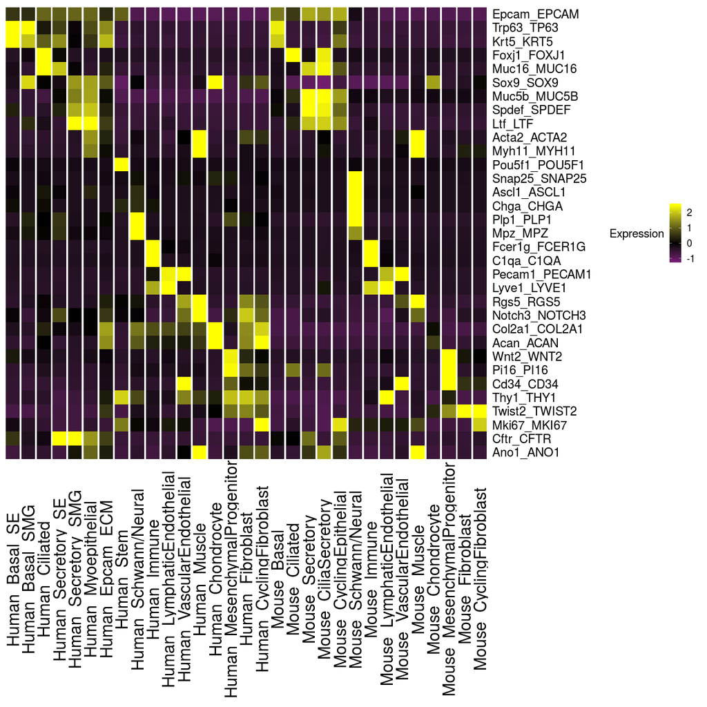